# DV_RProject1

**Authors: Rolando Melendez, Hyunji Seo, Catherine Tu**

### This is how our RStudio is configured:

```r
#Shows the subset and summary of the data frame
source("../01 Data/TitanicData.R", echo = TRUE)
```

```
##
## > require("jsonlite")
```

```
##
## > require("RCurl")
```

```
##
## > df <- data.frame(fromJSON(getURL(URLencode("129.152.144.84:5001/rest/native/?query=\"select * from titanic\""),
## +     httpheader = c(DB = "jdbc:ora ..." ... [TRUNCATED]
##
## > head(df)
##   PASSENGERID SURVIVED PCLASS                                  NAME    SEX
## 1         311        1      1        Hays, Miss. Margaret Bechstein female
## 2         312        1      1            Ryerson, Miss. Emily Borie female
## 3         313        0      2 Lahtinen, Mrs. William (Anna Sylfven) female
## 4         314        0      3                Hendekovic, Mr. Ignjac   male
## 5         315        0      2                    Hart, Mr. Benjamin   male
## 6         316        1      3       Nilsson, Miss. Helmina Josefina female
##   AGE SIBSP PARCH       TICKET             FARE           CABIN EMBARKED
## 1  24     0     0        11767 83.1583023071289             C54        C
## 2  18     2     2     PC 17608          262.375 B57 B59 B63 B66        C
## 3  26     1     1       250651               26            null        S
## 4  28     0     0       349243 7.89580011367798            null        S
## 5  43     1     1 F.C.C. 13529            26.25            null        S
## 6  26     0     0       347470 7.85419988632202            null        S
##
## > summary(df)
##                                       PASSENGERID  SURVIVED    PCLASS
##  </pre></body></html>Xtext/csvUUTF-8(?N`vPJS:  1   0   :549   1   :216
##  1                                          :  1   1   :342   2   :184
##  10                                         :  1   null:  2   3   :491
##  100                                        :  1              null:  2
##  101                                        :  1
##  102                                        :  1
##  (Other)                                    :887
##                                     NAME         SEX           AGE
##  null                                 :  2   female:314   null   :179
##  Abbing, Mr. Anthony                  :  1   male  :577   24     : 30
##  Abbott, Mr. Rossmore Edward          :  1   null  :  2   22     : 27
##  Abbott, Mrs. Stanton (Rosa Hunt)     :  1                18     : 26
##  Abelson, Mr. Samuel                  :  1                19     : 25
##  Abelson, Mrs. Samuel (Hannah Wizosky):  1                28     : 25
##  (Other)                              :886                (Other):581
##      SIBSP         PARCH          TICKET                  FARE
##  0      :608   0      :678   1601    :  7   8.05000019073486: 43
##  1      :209   1      :118   347082  :  7   13              : 42
##  2      : 28   2      : 80   CA. 2343:  7   7.89580011367798: 38
##  4      : 18   3      :  5   3101295 :  6   7.75            : 34
##  3      : 16   5      :  5   347088  :  6   26              : 31
##  8      :  7   4      :  4   CA 2144 :  6   10.5            : 24
##  (Other):  7   (Other):  3   (Other) :854   (Other)         :681
##          CABIN     EMBARKED
##  null       :689   C   :168
##  B96 B98    :  4   null:  4
##  C23 C25 C27:  4   Q   : 77
##  G6         :  4   S   :644
##  C22 C26    :  3
##  D          :  3
##  (Other)    :186
```

### Visualization 1

```r
source("../02 Visualizations/TitanicVisualization_1.R", echo = TRUE)
```

```
##
## > df1 <- df
##
## > require(extrafont)
```

```
## Registering fonts with R
```

```
##
## > require(ggplot2)
```

```
##
## > ggplot() + coord_cartesian() + scale_x_continuous() +
## +     scale_y_continuous() + labs(title = "Titanic") + labs(x = "Age",
## +     y = paste("Fare ..." ... [TRUNCATED]
```

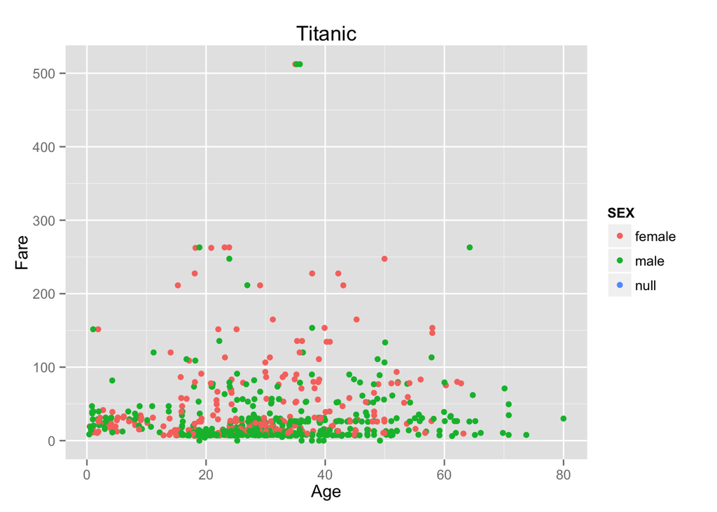

#### **Method:**

In Visualization 1, We compared data based on Age and Fare between males, females, and null values. We copied the data frame into a new local data frame, set x and y as continuous, followed by giving them their corresponding labels. The layer in this visualization set the axis; x with age values and y with fare values. It is a point plot that graphs the people’s age and corresponding fares in the x/y axis repectively, and the legend is separated and colored by sex.

#### **Findings:**

There did not seem to be a real trend between Age and Fare. Most people in general payed the lower fares regardless of age. Few of them payed in the mid-range, and a few seemed like outliers paying in the highest range.

### Visualization 2

```r
source("../02 Visualizations/TitanicVisualization_2.R", echo = TRUE)
```

```
##
## > df2 <- subset(df, SEX == "female" | SEX == "male")
##
## > require(extrafont)
##
## > require(ggplot2)
##
## > ggplot() + coord_cartesian() + scale_x_continuous() +
## +     scale_y_continuous() + labs(title = "Titanic") + labs(x = "Age",
## +     y = paste("Fare ..." ... [TRUNCATED]
```

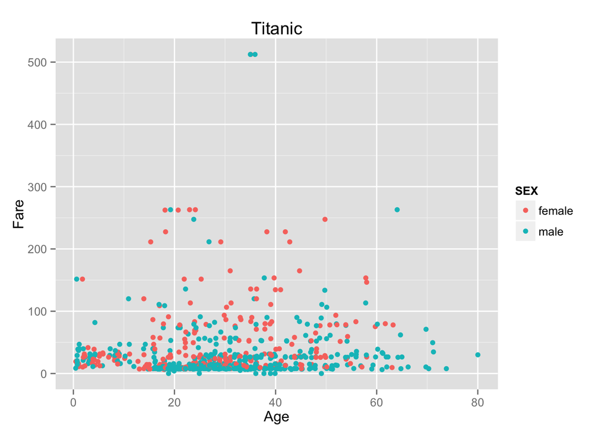

#### **Method:**

In Visualization 2, Like in Visualization 1 we compared data based on Age and Fare between males, females, but not null values this time. We copied the data frame into a new local data frame, set x and y as continuous, followed by giving them their corresponding labels. The layer in this visualization set the axis; x with age values and y with fare values. It is a point plot that graphs the people’s age and corresponding fares in the x/y axis repectively, and the legend is seperated and colored by sex.

#### **Findings:**

Again there did not seem to be a real trend between Age and Fare. Most people in general payed the lower fares regardless of age. Few of them payed in the mid-range, and a few seemed like outliers paying in the highest range.

### Visualization 3

```r
source("../02 Visualizations/TitanicVisualization_3.R", echo = TRUE)
```

```
##
## > df3 <- subset(df, SEX == "female" | SEX == "male")
##
## > require(extrafont)
##
## > require(ggplot2)
##
## > ggplot() + coord_cartesian() + scale_x_discrete() +
## +     scale_y_continuous() + labs(title = "Titanic") + labs(x = "SURVIVED",
## +     y = paste("F ..." ... [TRUNCATED]
```

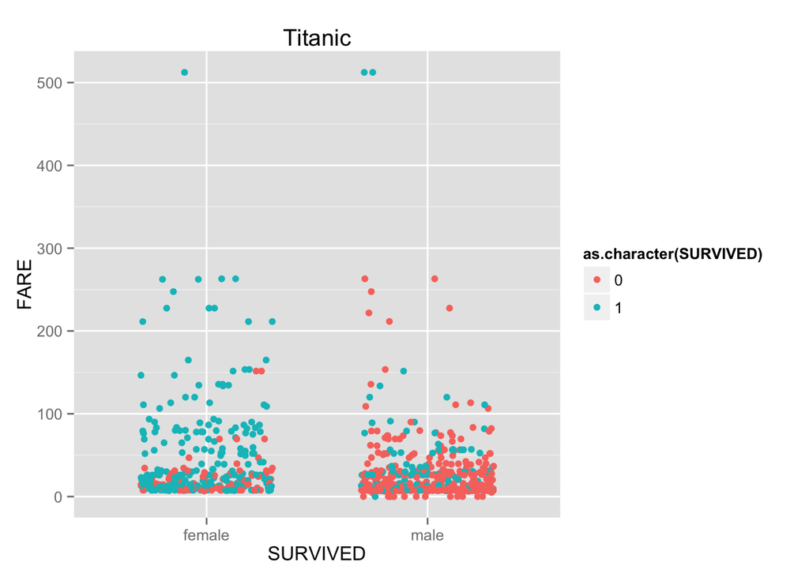

#### **Method:**

In Visualization 3, we displayed the survival distribution based on Sex and Fare. We copied the data frame into a new local data frame, set x as discrete and y as continuous, followed by giving them their corresponding labels. The layer in this visualization set x as Sex and y as Fare. It is a point plot that graphs the people’s sex and corresponding fares in the x/y axis repectively, and the legend is separated and colored by whether the passengers survived or not.

#### **Findings:**

This visualization indicates that a greater proportion of the females survived, as compared to males, generally regardless of fare. Some females in the mid-range fare did not survive, while some males in the mid-range fare did survive. In addition, two males who paid above $500 survived.

### Visualization 4

```r
source("../02 Visualizations/TitanicVisualization_4.R", echo = TRUE)
```

```
##
## > df4 <- subset(df, SEX == "female" | SEX == "male")
##
## > require(extrafont)
##
## > require(ggplot2)
##
## > ggplot() + coord_cartesian() + scale_x_discrete() +
## +     scale_y_continuous() + facet_grid(PCLASS ~ SURVIVED, labeller = label_both) +
## +     labs .... [TRUNCATED]
```

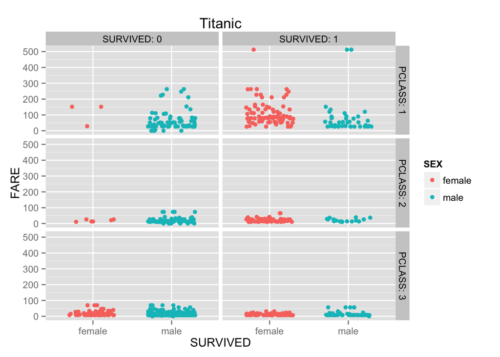

#### **Method:**

In Visualization 4, we displayed the survival distribution based on Sex, Fare, and Passenger Class. We copied the data frame into a new local data frame, set x as discrete and y as continuous, followed by giving them their corresponding labels. In this visualization, we added a facet to create a matrix, with rows by passenger class and columns by survival. The layer in this visualization set x as Sex and y as Fare. It is a point plot that graphs the people’s sex and corresponding fares in the x/y axis repectively, and the legend is separated and colored by passenger sex.

### Visualization 5

```r
source("../02 Visualizations/TitanicVisualization_5.R", echo = TRUE)
```

```
##
## > df5 <- subset(df, as.numeric(as.character(AGE)) <=
## +     10 & (SEX == "female" | SEX == "male"))
```

```
##
## > require(extrafont)
##
## > require(ggplot2)
##
## > ggplot() + coord_cartesian() + scale_x_discrete() +
## +     scale_y_continuous() + facet_grid(PCLASS ~ SURVIVED, labeller = label_both) +
## +     labs .... [TRUNCATED]
```

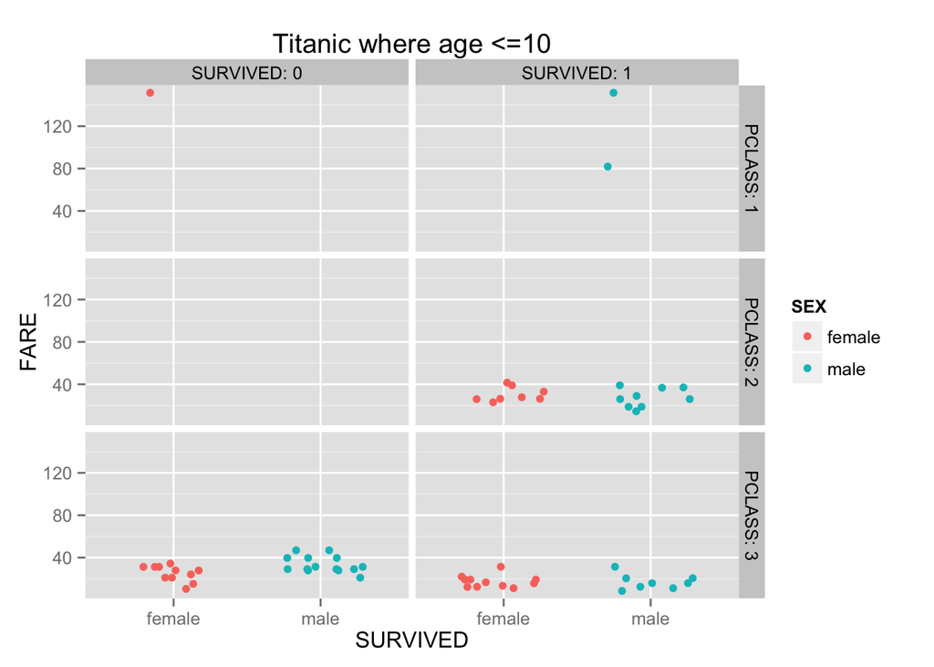

#### **Method:**

In Visualization 5, we compared the survival distribution of child passengers based on Sex, Fare, and Class. We copied the dataframe into a local data frame, set x as discrete and y as continuous and labeled both accordingly. A facet was added to create a matrix, with rows by passenger class and columns by survival, also labeled accordingly. The layer in this visualization set x as Sex and y as Fare. It is separate point plots that graph the children’s sex and corresponding fare costs based on passenger class and survival result, and the legend is colored by passenger sex.

#### **Findings:**

From the visualization, we found that there was not much of a difference in survivability between sexes; passenger class was a greater indicator of survivability. More children survived in passenger classes 1 & 2, than those in passenger class 3. It seems also possible that there’s a positive correlation between fare and passenger class (as passenger class goes higher from 3 to 1, the average fare cost increases). ***

### Visualization 6

```r
source("../02 Visualizations/TitanicVisualization_6.R", echo = TRUE)
```

```
##
## > df6 <- subset(df, as.numeric(as.character(AGE)) >=
## +     40 & (SEX == "female" | SEX == "male"))
```

```
##
## > require(extrafont)
##
## > require(ggplot2)
##
## > ggplot() + coord_cartesian() + scale_x_discrete() +
## +     scale_y_continuous() + facet_grid(PCLASS ~ SURVIVED, labeller = label_both) +
## +     labs .... [TRUNCATED]
```

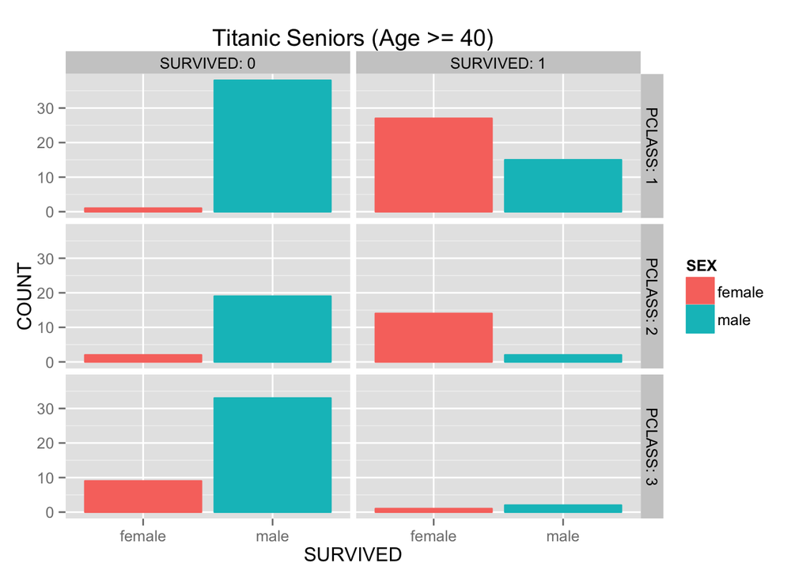

#### **Method:**

In Visualization 6, we compared the survival distribution of elderly passengers based on Sex and Passenger Class. We defined “seniors” as anyone at least 40 years old, because the life expectancy of UK was around 51 for males and 55 for females, according to [an article](http://www.independent.co.uk/life-style/health-and-families/health-news/life-expectancy-in-britain-almost-30-years-higher-than-a-century-ago-10481491.html) from the Independent. We copied the dataframe into a local dataframe, set x as discrete and y as continuous and labeled both accordingly. A facet was added to create a matrix, with rows by passenger class and columns by survival, also labeled accordingly. The layer in this visualization set x as Sex and y as Count, because we wanted to display relevant information in a bar graph.The bar graph visualizes seniors’ survival based on passenger class and the legend is colored by passenger sex.

#### **Findings:**

We found that among the seniors, females were more likely to survive in all three passenger classes; the ratio of female seniors who survived to those who did not survive is larger than the ratio of that of male seniors. We also found that seniors of classes 1 & 2 were more likely to survive than those of passenger class 3. These findings align with the statement that children and women were placed in lifeboats before others.